# Regularization

## Background Information

Throughout this semester, we have discussed a variety of regression techniques, from multiple linear regression to polynomial regression to generalized linear models to non-linear regression to mixed effects models to time series models. We have also discussed methods to choose the appropriate model parameters via confidence intervals, hypothesis tests, variable selection, etc.

All of the above methods we have previously discussed revolved around **inference**, meaning we are interested in describing the relationship between explanatory variables $\boldsymbol{x}_i$ and the response variable $y_i$ for $i = 1,\dots,n$. Today, we will discuss methods of linear regression that are used in **prediction**.

Note, throughout this set of notes, we will assume the data follows a linear regression format:

$$y_i = \boldsymbol{x}_i\boldsymbol{\beta} + \epsilon_i$$
$$\epsilon_i \sim \mathcal{N}(0,\sigma^2)$$

### Example

Consider the mtcars dataset in R. Suppose we want to use the data to predict a car’s fuel effciency by its weight.

- In the below example, we are interested in using the regression line calculated from the points in blue to predict the points in red. In other words we can say:
  - *In-sample* data: blue points
  - *Out-of-sample* data: red points

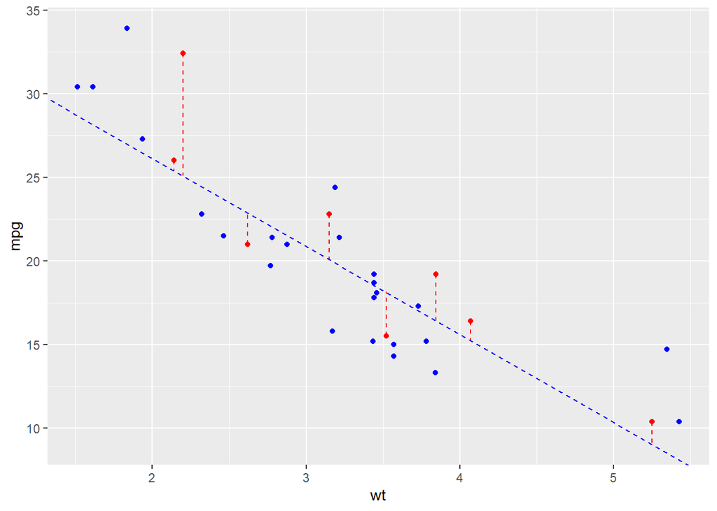

```r
library(tidyverse)
# Split data into training and testing sets
set.seed(10062018)
train_index <- sample(1:nrow(mtcars), size = 0.75 * nrow(mtcars))
train_data <- mtcars[train_index, ]
test_data <- mtcars[-train_index, ]
train_data$Type <- "Train"
test_data$Type <- "Test"

mod <- lm(mpg ~ wt,train_data)
x_test <- as.matrix(test_data[, -1])
y_test <- test_data$mpg

y_pred <- predict(mod,data.frame(wt=test_data$wt))

ggplot() +
  geom_point(data=train_data,aes(x=wt,y=mpg),colour="blue") +
  geom_point(data=test_data,aes(x=wt,y=mpg),colour="red") +
  geom_abline(aes(intercept=coef(mod)[1],slope=coef(mod)[2]),linetype=2,colour="blue") +
  geom_segment(aes(x=test_data$wt,xend=test_data$wt,y=y_test,yend=y_pred),colour="red",linetype=2)
```

What is the mean and variance of the residuals from the least squares regression line (points in blue)?

- Because these data points are not used in the estimation of the model parameters, we have introduced **prediction bias** into our out-of-sample testing, hence why the variance of the out-of-sample residuals is higher.

**Regularization**: A modern regression technique where we add a regularization or penalty term to the least squares regression equation to incorporate the prediction bias into our model. These modern methods are called **constrained least squares**

$$\hat{\boldsymbol{\beta}} = \min_\boldsymbol{\beta} \sum_{i=1}^n (y_i - \boldsymbol{x}_i\boldsymbol{\beta})^2 \text{ subject to } R(\boldsymbol{\beta}) \leq t$$

or equivalently

$$\hat{\boldsymbol{\beta}} = \min_\boldsymbol{\beta} \sum_{i=1}^n (y_i - \boldsymbol{x}_i\boldsymbol{\beta})^2 + \lambda R(\boldsymbol{\beta})$$

In the above formula

- $R(\boldsymbol{\beta})$ is the penalty or regularizer term and
- $\lambda > 0$ is the smoothing parameter controlling how much influence the penalty term has on $\hat{\boldsymbol{\beta}}$

There are two common regularization terms we will discuss

- (Least Absolute Shrinkage Selection Operator) LASSO regression: $R(\boldsymbol{\beta}) = \sum_{i=1}^p |\beta_j|$
- Ridge regression: $R(\boldsymbol{\beta}) = \sum_{i=1}^p \beta_j^2$
- Note: The intercept terms are not included in the calculation of the penalty terms.

What is the difference between the two regularization types? Let’s visualize this by what happens to the regression lines for the mtcars model for different values of $\lambda$. (Note: We will start using the whole dataset now instead of splitting it.)

### LASSO Regression Example

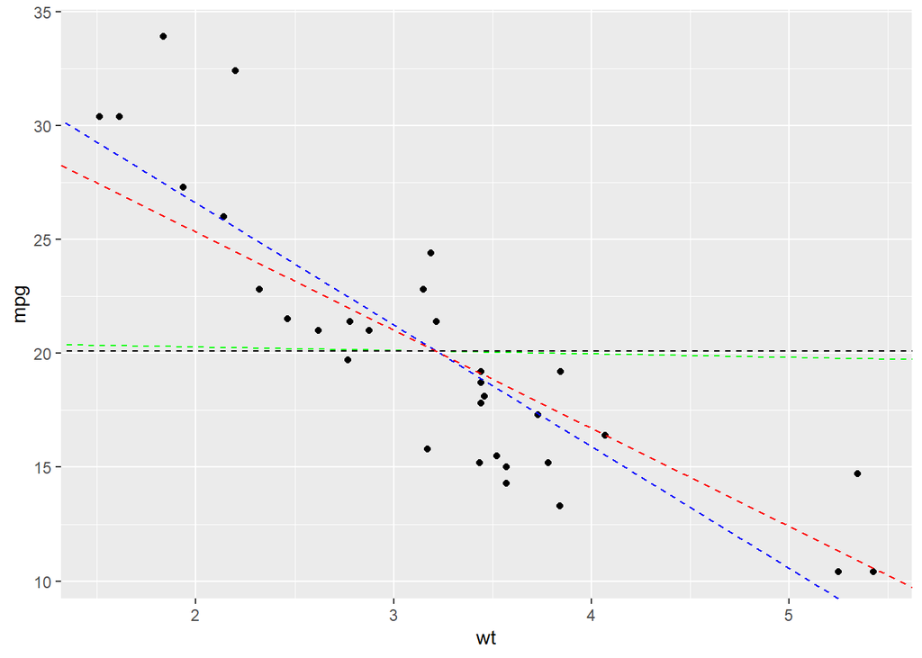

```r
# Library used for constrained linear regression
library(glmnet)
# glmnet performs constrained regression for a given model matrix and response variable
# alpha = 1 means LASSO regression
X <- model.matrix(~ wt,mtcars)
Y <- mtcars$mpg
mod_0 <- glmnet(X,Y, alpha = 1, lambda = 0)
mod_1 <- glmnet(X,Y, alpha = 1, lambda = 1)
mod_5 <- glmnet(X,Y, alpha = 1, lambda = 5)
mod_10 <- glmnet(X,Y, alpha = 1, lambda = 10)

ggplot() +
  geom_point(data=mtcars,aes(x=wt,y=mpg)) +
  geom_abline(aes(intercept=coef(mod_0)[1],slope=coef(mod_0)[3]),linetype=2,colour="blue") +
  geom_abline(aes(intercept=coef(mod_1)[1],slope=coef(mod_1)[3]),linetype=2,colour="red") +
  geom_abline(aes(intercept=coef(mod_5)[1],slope=coef(mod_5)[3]),linetype=2,colour="green") +
  geom_abline(aes(intercept=coef(mod_10)[1],slope=coef(mod_10)[3]),linetype=2,colour="black")
```

### Ridge Regression Example

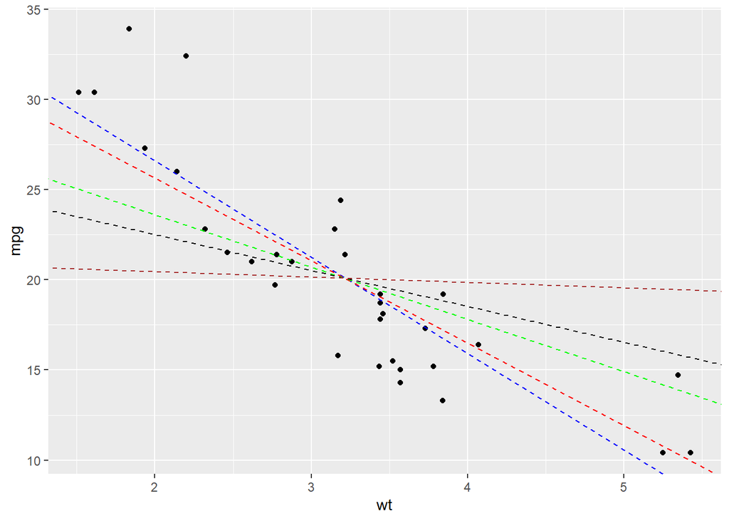

```r
# glmnet performs constrained regression for a given model matrix and response variable
# alpha = 0 means ridge regression
X <- model.matrix(~ wt,mtcars)
Y <- mtcars$mpg
mod_0 <- glmnet(X,Y, alpha = 0, lambda = 0)
mod_1 <- glmnet(X,Y, alpha = 0, lambda = 1)
mod_5 <- glmnet(X,Y, alpha = 0, lambda = 5)
mod_10 <- glmnet(X,Y, alpha = 0, lambda = 10)
mod_100 <- glmnet(X,Y, alpha = 0, lambda = 100)

ggplot() +
  geom_point(data=mtcars,aes(x=wt,y=mpg)) +
  geom_abline(aes(intercept=coef(mod_0)[1],slope=coef(mod_0)[3]),linetype=2,colour="blue") +
  geom_abline(aes(intercept=coef(mod_1)[1],slope=coef(mod_1)[3]),linetype=2,colour="red") +
  geom_abline(aes(intercept=coef(mod_5)[1],slope=coef(mod_5)[3]),linetype=2,colour="green") +
  geom_abline(aes(intercept=coef(mod_10)[1],slope=coef(mod_10)[3]),linetype=2,colour="black") +
    geom_abline(aes(intercept=coef(mod_100)[1],slope=coef(mod_100)[3]),linetype=2,colour="brown")
```

## Differences of LASSO and Ridge

- LASSO simplifies models by reducing the number of explanatory variables, helping to increase interpretability, often used in variable selection
- Ridge helps to control for overfitting by reducing the magnitude of the coefficients, while leaving all of the explanatory variables in the model

## A Combination of LASSO and Ridge

- Elastic-Net is a linear combination of LASSO and Ridge penalty terms in the model.

  $$R(\boldsymbol{\beta}) = \lambda(\alpha\sum_{i=1}^p |\beta_i| + (1-\alpha)\sum_{i=1}^p \beta_i^2)$$

## Finding $\hat{\boldsymbol{\beta}}$ and $\hat{\lambda}$

When the goal of regression estimation is *prediction* rather than *inference*, we want to choose the values of the regression parameters $\boldsymbol{\beta}$ that minimize the *out-of-sample variance* rather than the *in-sample variance*.

**Prediction Error**: The difference between an *out-of-sample* value of the response $y_i'$ and its prediction using the *in-sample* regression estimates $\hat{\boldsymbol{\beta}}$ for $i = 1,\cdots,n'$

$$\text{PE} = y_i' - \boldsymbol{x}_i'\hat{\boldsymbol{\beta}}$$

**Mean Squared Prediction Error**: The average prediction error for all data points in the *out-of-sample* dataset.

$$\text{MSPE} = \frac{1}{n'}\sum_{i=1}^{n'} (y_i' - \boldsymbol{x}_i'\hat{\boldsymbol{\beta}})^2$$

In problems where the ultimate goal is prediction rather than inference, we want to find the values of $\boldsymbol{\beta}$ and $\lambda$ that minimize the **MSPE**.

- However, in reality, we cannot calculate a prediction on data that we do not observe! So we need to use a method to approximate the MSPE

**Cross Validation**: A resampling and sample splitting methods that use different portions of the data to test and train a model on different iterations.

In other words we split the data into *training* and *test* data where we:

1. Fit the constrained regression model using the *training* data
2. Calculate the MSPE using the *test* data

However, we don’t want to arbitrarily choose points to be in the training data or the test data. We want to use all points to be incorporated in the approximation of the MSPE.

**K-Fold Cross Validation**: A cross validation technique where the data points are randomly placed into $K$ subgroups, and regression is performed as follows, for a given value of $\lambda$

- Separate Data into subgroups $F_1, \cdots, F_K$

For $k$ in $1:K$

- Calculate
  $$\hat{\boldsymbol{\beta}}^{-k} = \min_\boldsymbol{\beta} \sum_{i \notin F_k} (y_i - \boldsymbol{x}_i \boldsymbol{\beta}) + \lambda R(\boldsymbol{\beta})$$
  using the data NOT in subgroup $k$
- Calculate the *total error* of the test data set
  $$e_k(\lambda) = \sum_{i \in F_k}(y_i - \boldsymbol{x}_i \hat{\boldsymbol{\beta}}^{-k})^2$$

End For

- Calculate the estimate of the MSPE

$$\hat{MSPE} = \frac{1}{n} \sum_{k=1}^K e_k(\lambda)$$

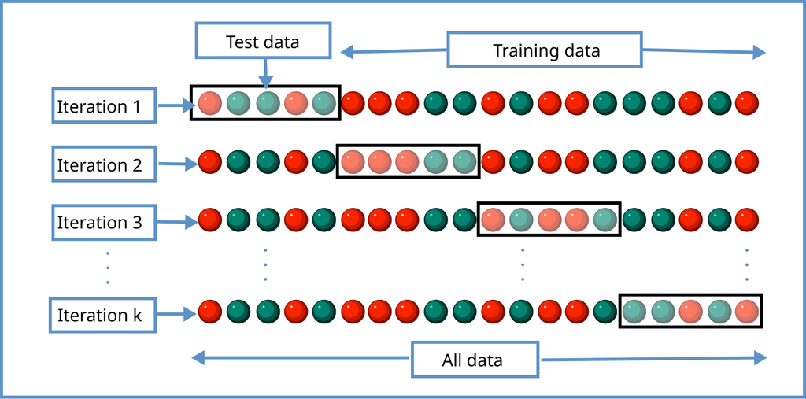

Typically $K = 5$ or $K = 10$ are common choices. We use $K$-fold cross validation in order to choose the optimal value of $\lambda$ to use in constrained regression.

Two choices are typically used

- $\hat{\lambda}$, the value of $\lambda$ that minimizes the $\hat{MSPE}$
- $\tilde{\lambda} = \hat{\lambda} + SE(\hat{\lambda})$, the one-plus standard error estimate (This helps to choose a more regularized model)

## Example

Find the optimal value of $\lambda$ that minimizes the MSPE in LASSO, ridge, and elastic net regression using $K = 5$-fold cross validation for the entire mtcars dataset.

Using your estimates of $\lambda$, calculate the prediction lines for the mtcars dataset via LASSO, ridge, and elastic net regression.